# DATA 606 Final Project

## Decision Tree

Decision trees create a set of binary splits on the predictor variables in order to create a tree that can be used to classify new observations into one of two groups. Here, we will be using classical trees. The algorithm of this model is the following:

Choose the predictor variable that best splits the data into two groups;

Separate the data into these two groups;

Repeat these steps until a subgroup contains fewer than a minimum number of observations;

To classify a case, run it down the tree to a terminal node, and assign it the model outcome value assigned in the previous step.

```r
set.seed(42)
sample <- sample.int(n = nrow(my_loan_data_1), size = floor(.70*nrow(my_loan_data_1)), replace = F)
trainnew <- my_loan_data_1[sample, ]
testnew  <- my_loan_data_1[-sample, ]
```

```r
dtree <- rpart(Loan_Status ~ Credit_History + Education + Self_Employed + Property_Area + LoanAmount +
                 ApplicantIncome, method="class", data=traindf,parms=list(split="information"))
dtree$cptable
```

```
##           CP nsplit rel error    xerror       xstd
## 1 0.40769231      0 1.0000000 1.0000000 0.07299480
## 2 0.01346154      1 0.5923077 0.5923077 0.06104778
## 3 0.01000000      5 0.5384615 0.6384615 0.06282970
```

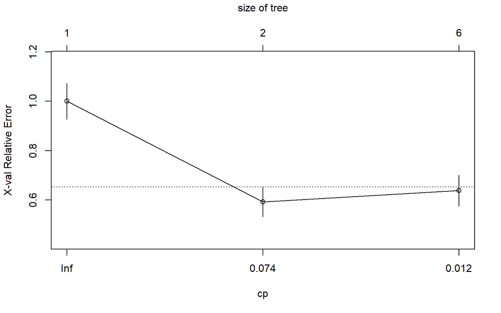

```r
plotcp(dtree)
```

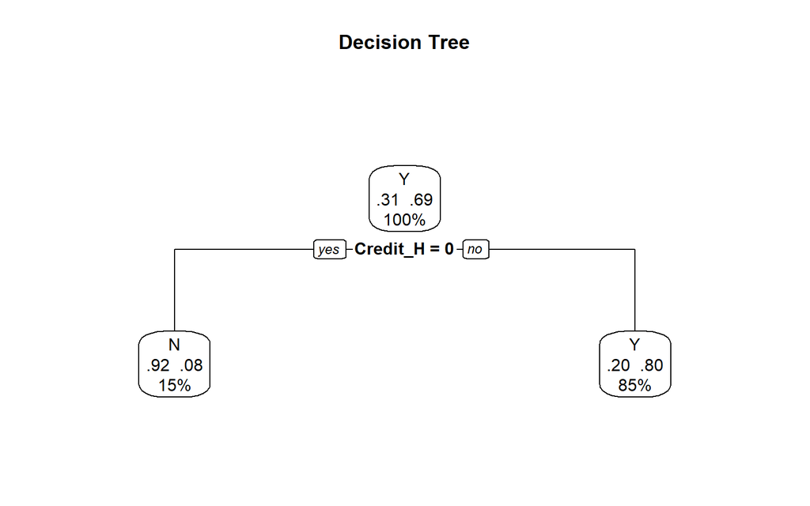

```r
dtree.pruned <- prune(dtree, cp=.02290076)
library(rpart.plot)
prp(dtree.pruned, type = 2, extra = 104,
    fallen.leaves = TRUE, main="Decision Tree")
```

```r
dtree.pred <- predict(dtree.pruned, trainnew, type="class")
dtree.perf <- table(trainnew$Loan_Status, dtree.pred,
                    dnn=c("Actual", "Predicted"))
dtree.perf
```

```
##       Predicted
## Actual   N   Y
##      N  49  64
##      Y   5 252
```

```r
dtree_test <- rpart(Loan_Status ~ Credit_History+Education+Self_Employed+Property_Area+LoanAmount+
                 ApplicantIncome,method="class", data=testnew,parms=list(split="information"))
dtree_test$cptable
```

```
##     CP nsplit rel error xerror       xstd
## 1 0.42      0      1.00   1.00 0.11709266
## 2 0.01      1      0.58   0.58 0.09738725
```

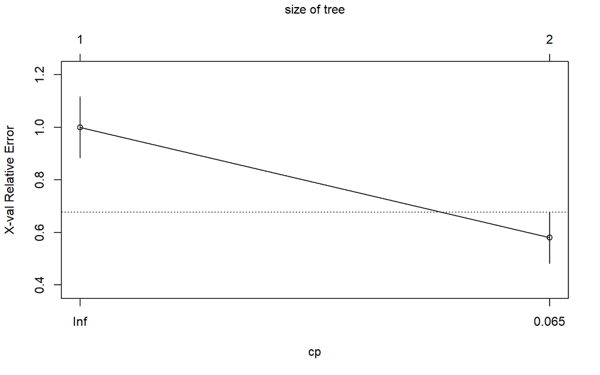

```r
plotcp(dtree_test)
```

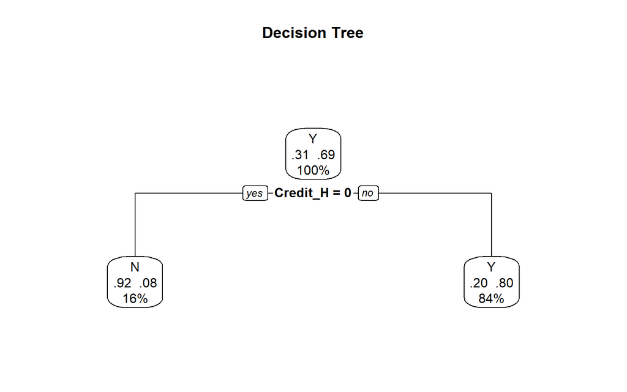

```r
dtree_test.pruned <- prune(dtree_test, cp=.01639344)
prp(dtree_test.pruned, type = 2, extra = 104,
    fallen.leaves = TRUE, main="Decision Tree")
```

## Random Forest

```r
set.seed(42)
fit.forest <- randomForest(Loan_Status ~ Credit_History+Education+Self_Employed+Property_Area+LoanAmount+
                             ApplicantIncome, data=trainnew,
                           na.action=na.roughfix,
                           importance=TRUE)
fit.forest
```

```
##
## Call:
##  randomForest(formula = Loan_Status ~ Credit_History + Education +      Self_Employed + Property_Area + LoanAmount + ApplicantIncome,      data = trainnew, importance = TRUE, na.action = na.roughfix)
##                Type of random forest: classification
##                      Number of trees: 500
## No. of variables tried at each split: 2
##
##         OOB estimate of  error rate: 18.65%
## Confusion matrix:
##    N   Y class.error
## N 53  60  0.53097345
## Y  9 248  0.03501946
```

```r
importance(fit.forest, type=2)
```

```
##                 MeanDecreaseGini
## Credit_History         41.890029
## Education               3.328873
## Self_Employed           4.921181
## Property_Area           8.718707
## LoanAmount             29.449887
## ApplicantIncome        29.320255
```

```r
forest.pred <- predict(fit.forest, testnew)
forest.perf <- table(testnew$Loan_Status, forest.pred,
                     dnn=c("Actual", "Predicted"))
forest.perf
```

```
##       Predicted
## Actual   N   Y
##      N  24  26
##      Y   5 104
```

Here is the accuracy of the model: 80.50%

## Conclusion

The dataset is relatively small. A larger dataset will help to improve the model accuracy.

We can conclude that the company should target customers with Credit history and customer who lives in Semiurban area.

## Reference

https://datahack.analyticsvidhya.com/contest/practice-problem-loan-prediction-iii/

Forhad Akbar

12/04/2019